# Rose Project 2

## 9. Based on the model-building exercise, build the most optimum model(s) on the complete data and predict 12 months into the future with appropriate confidence intervals/bands

```python
fullmodel1 = ExponentialSmoothing(df,
                                  trend='additive',
                                  seasonal='multiplicative').fit(smoothing_level=0.3,
                                                                 smoothing_trend=0.4,
                                                                 smoothing_seasonal=0.3)
```

```python
RMSE_fullmodel1 = metrics.mean_squared_error(df['Rose'],fullmodel1.fittedvalues,squared=False)

print('RMSE:',RMSE_fullmodel1)
```

```
RMSE: 20.67087253508064
```

```python
# Getting the predictions for the same number of times stamps that are present in the test data
prediction_1 = fullmodel1.forecast(steps=len(test))
```

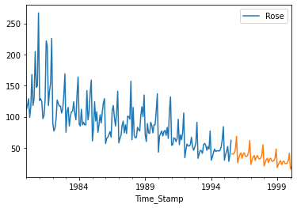

```python
df.plot()
prediction_1.plot();
```

```python
#n the below code, we have calculated the upper and lower confidence bands at 95% confidence level
#Here we are taking the multiplier to be 1.96 as we want to plot with respect to a 95% confidence intervals.
prediction_1 = pd.DataFrame({'lower_CI':prediction_1 - 1.96*np.std(fullmodel1.resid,ddof=1),
                          'prediction':prediction_1,
                          'upper_ci': prediction_1 + 1.96*np.std(fullmodel1.resid,ddof=1)})
prediction_1.head()
```

|  | lower_CI | prediction | upper_ci |
| --- | --- | --- | --- |
| 1995-08-31 | -0.399538 | 40.209004 | 80.817547 |
| 1995-09-30 | -0.898136 | 39.710407 | 80.318950 |
| 1995-10-31 | 1.042710 | 41.651253 | 82.259795 |
| 1995-11-30 | 7.583437 | 48.191980 | 88.800522 |
| 1995-12-31 | 27.885705 | 68.494248 | 109.102790 |

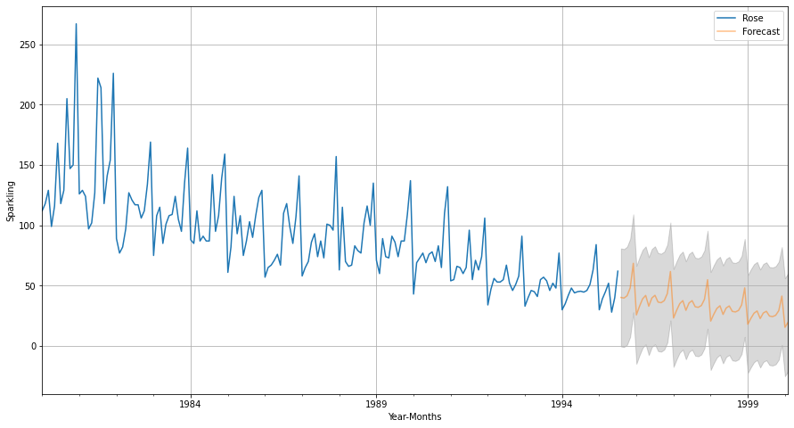

```python
# plot the forecast along with the confidence band

axis = df.plot(label='Actual', figsize=(15,8))
prediction_1['prediction'].plot(ax=axis, label='Forecast', alpha=0.5)
axis.fill_between(prediction_1.index,prediction_1['lower_CI'], prediction_1['upper_ci'], color='k', alpha=.15)
axis.set_xlabel('Year-Months')
axis.set_ylabel('Sparkling')
plt.legend(loc='best')
plt.grid()
plt.show()
```

```python
full_data_model = sm.tsa.statespace.SARIMAX(df['Rose'],
                                order=(2,1,3),
                                seasonal_order=(2, 0, 3, 6),
                                enforce_stationarity=False,
                                enforce_invertibility=False)
results_full_data_model = full_data_model.fit(maxiter=1000)
print(results_full_data_model.summary())
```

```
                                     SARIMAX Results
=========================================================================================
Dep. Variable:                              Rose   No. Observations:                  187
Model:             SARIMAX(2, 1, 3)x(2, 0, 3, 6)   Log Likelihood                -675.256
Date:                           Sat, 25 Dec 2021   AIC                           1372.512
Time:                                   22:25:32   BIC                           1406.611
Sample:                               01-31-1980   HQIC                          1386.355
                                    - 07-31-1995
Covariance Type:                             opg
==============================================================================
                 coef    std err          z      P>|z|      [0.025      0.975]
------------------------------------------------------------------------------
ar.L1         -0.5257      0.061     -8.685      0.000      -0.644      -0.407
ar.L2         -0.6847      0.054    -12.742      0.000      -0.790      -0.579
ma.L1         -0.2432      0.072     -3.373      0.001      -0.385      -0.102
ma.L2          0.2349      0.074      3.188      0.001       0.090       0.379
ma.L3         -0.7576      0.075    -10.090      0.000      -0.905      -0.610
ar.S.L6       -0.0542      0.034     -1.619      0.105      -0.120       0.011
ar.S.L12       0.8638      0.034     25.307      0.000       0.797       0.931
ma.S.L6        0.1693      4.022      0.042      0.966      -7.713       8.052
ma.S.L12      -0.6534      3.337     -0.196      0.845      -7.193       5.886
ma.S.L18       0.1745      0.749      0.233      0.816      -1.293       1.642
sigma2       197.9963    793.627      0.249      0.803   -1357.483    1753.476
===================================================================================
Ljung-Box (L1) (Q):                   0.35   Jarque-Bera (JB):                18.17
Prob(Q):                              0.56   Prob(JB):                         0.00
Heteroskedasticity (H):               0.21   Skew:                            -0.30
Prob(H) (two-sided):                  0.00   Kurtosis:                         4.51
===================================================================================

Warnings:
[1] Covariance matrix calculated using the outer product of gradients (complex-step).
```

```python
predicted_manual_SARIMA_full_data = results_full_data_model.get_forecast(steps=12)
```

```python
pred_full_manual_SARIMA_date = predicted_manual_SARIMA_full_data.summary_frame(alpha=0.05)
pred_full_manual_SARIMA_date.head()
```

| Rose | mean | mean_se | mean_ci_lower | mean_ci_upper |
| --- | --- | --- | --- | --- |
| 1995-08-31 | 52.472326 | 14.294287 | 24.456038 | 80.488614 |
| 1995-09-30 | 45.750077 | 14.670909 | 16.995623 | 74.504532 |
| 1995-10-31 | 48.504538 | 14.908610 | 19.284199 | 77.724877 |
| 1995-11-30 | 54.224074 | 14.911193 | 24.998674 | 83.449475 |
| 1995-12-31 | 72.342925 | 15.007035 | 42.929678 | 101.756173 |

```python
rmse = mean_squared_error(df['Rose'],results_full_data_model.fittedvalues,squared=False)
print('RMSE of the Full Model',rmse)
```

```
RMSE of the Full Model 25.508743210097204
```

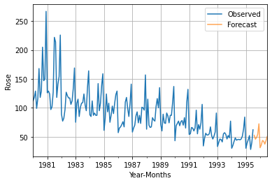

```python
axis = df['Rose'].plot(label='Observed')
pred_full_manual_SARIMA_date['mean'].plot(ax=axis, label='Forecast', alpha=0.7)

axis.set_xlabel('Year-Months')
axis.set_ylabel('Rose')
plt.legend(loc='best')
plt.grid();
```

## 10. Comment on the model thus built and report your findings and suggest the measures that the company should be taking for future sales

The recommendation to Business is to use “Triple Exponential model” to predict the wine sales for the future, as it errors minimum and predicts as good as the original sales.

Consumers get very excited about savings and appreciate discounts being passed on. Many prominent retailers also have loyalty programs or club member cards that create excitement. A club-member price brings consumers back and gives you an edge on your competition.

Need to arrange proper training to sales person, So they can convice the customer it seems to increase the sales.

In month which has low sales of wines need to arrange business events, weddings party, and summer concert series, and these are all great ways to leverage a stunning location to increase revenue.

The sales seem to be higher in the month of December and that obvious due to Christmas and new year celebrations. We can increase the production with proper advertisements will increase the sales. As per previous data sales will be decreased in beginning of the year so we need to deepdive and work on stratergies.

Sales person should post product regurly in social media will definetly increase the sales.

Wine sales is fluctuating over the month, So we need to get customer review based on that we make the decision.

There seems to be sales not increasing it is sometimes increasing and sometimes decreasing, so business has to act on quickly to improve their process and strategy to increase sale of this wine.

Wine outlet should adapt new trend to sale the wines. We need work deeply on cache advertisement,customer service and creating ambiance for customers